# bigdata_heart

Feiyang ZHANG

2023-03-29

# 1 Load Seurat Object

Here we run the same test again on the human heart sample. A single-cell sequencing data containing aroung 600,000 cells. We will test the performance of starTracer on the big sample at the same time.

data source：

[heart_single_cell_data](https://www.nature.com/articles/s41586-022-04817-8)

Check the number of cells:

```r
dim(heart_big)
```

```
## [1]  36601 592689
```

# 2 Run Time Test

## 2.1 starTracer Running Time Test

We run searchMarker 5 times.

```r
t.Star.heart <- c()
for(i in 1:5){
  print(paste0("calculating time:",i))
  t1 <- Sys.time()
  starTracer::searchMarker(heart_big,thresh.1 = 0.5,thresh.2 = 0.3,method = "del_MI",num = 3,gene.use = "HVG")
  t2 <- Sys.time()
  t <- t2-t1
  t.Star.heart <- append(t.Star.heart,t)
}
```

Let’s see the results.

```r
t.Star.heart #43.53778 44.84784 42.77564 47.77111 48.38172
```

```
## Time differences in secs
## [1] 43.53778 44.84784 42.77564 47.77111 48.38172
```

### visualization

We set thresh.1 to 0.5, thresh.2 to 0.3 and num to 3 to plot the top 3 marker genes.

```r
Idents(heart_big) <- heart_big$cell_type__ontology_label
test.heart.big <- starTracer::searchMarker(heart_big,thresh.1 = 0.5,thresh.2 = 0.3,num = 3,gene.use = "HVG")
```

```
## using cardiac muscle cell, fat cell, macrophage, endocardial cell, cardiac ventricle fibroblast, cardiac endothelial cell, cardiac neuron, endothelial cell of lymphatic vessel, vascular associated smooth muscle cell, pericyte cell, mast cell, lymphocyte, mesothelial cell as ident...
```

```
## using HVG as input features...
```

```
## max normalizing the matirx...
```

```
## screen genes in each cluster according to thresh.2
```

```
## calculating parameters...
```

```
## Using "RNA" as the assay to plot Heatmap...
```

```
## createing out put data...
```

```
## Analysing Complete!
```

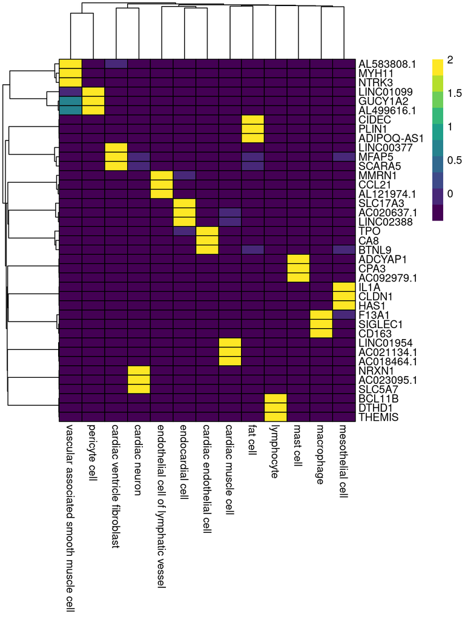

Dotplot:

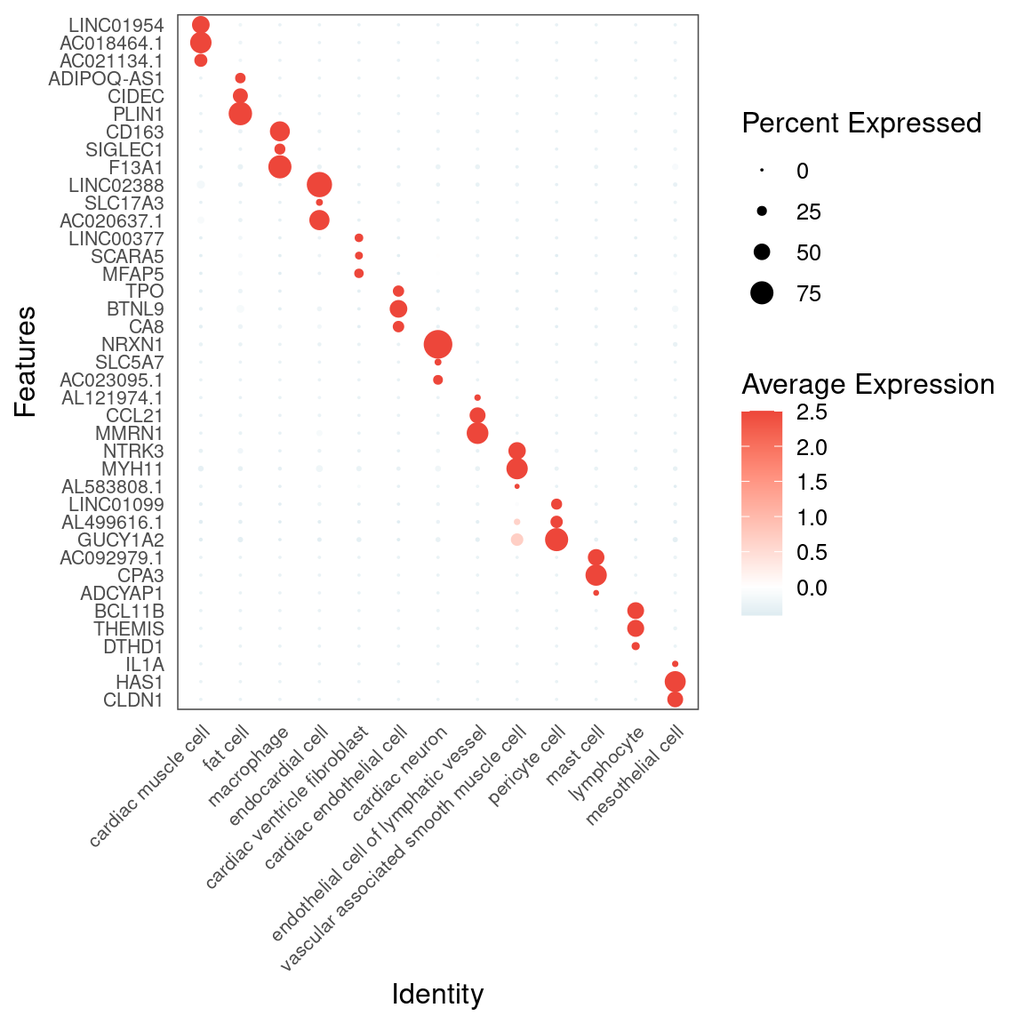

```r
(p <- use_dotplot(heart_big,features = test.heart.big$genes.markers, colors.gradient = c("#018daa","#ffffff","#ed463a")))
```

## 2.2 Seurat Running Time Test

This scripts takes around 30 hours for 5 runs.

```r
print("loading data")
load("./tmp/heart_big.Rdata")
print("loading data complete!")

print("setting...")
DefaultAssay(heart_big) <- "RNA"
Idents(heart_big) <- "cell_type__ontology_label"

print("running")
t.Seurat.heart <- c()
for(i in 1:5){
  t1 <- Sys.time()
  FindAllMarkers(heart_big,logfc.threshold = 0.5,only.pos = T)
  t2 <- Sys.time()
  t <- t2-t1 #10.99338/10.1306 secs 12.34614/12.43914/11.35643 for HVG
  t.Seurat <- append(t.Seurat,t)
}
save(t.Seurat.heart,file = "./out/f2_bigdata/t.Seurat.heart.Rdata")
print(t.Seurat.heart)
```

load the file. Each calculation takes around 6 hours.

```r
load("./out/f2_bigdata/t.Seurat.heart.Rdata")
t.Seurat.heart
```

```
## Time differences in hours
## [1] 6.424730 6.346148 6.346987 6.353355 6.302240
```

```r
#Time differences in hours
#[1] 6.424730 6.346148 6.346987 6.353355 6.302240
```

## 2.3 Find Difference

We use bar plot to show the difference of calculation time between `starTracer` and `Seurat`.

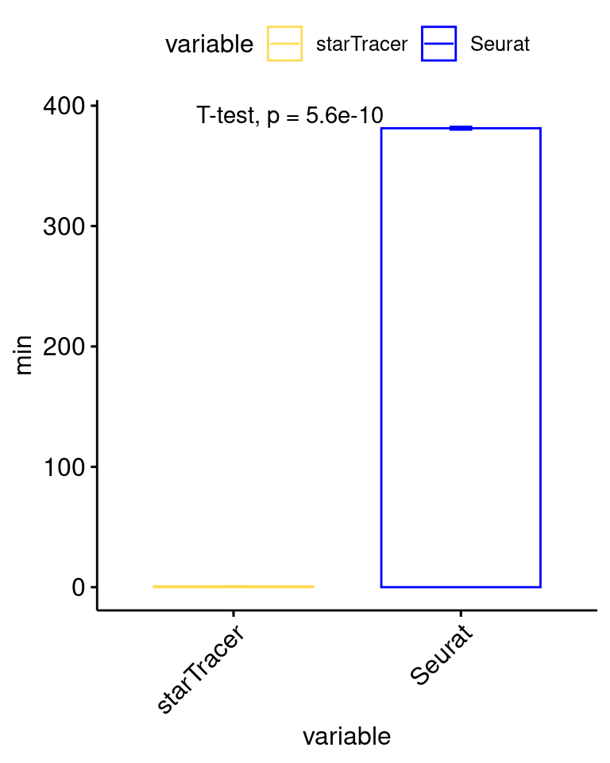

```r
time.1 <- as.numeric(t.Seurat.heart) * 60
time.2 <- as.numeric(t.Star.heart)/60
frame.time <- data.frame(starTracer = time.2, Seurat = time.1)
frame.time$RunTime <- 1:5 %>% as.vector()
mat.use <- reshape2::melt(frame.time,id = "RunTime")
(p <- ggbarplot(mat.use, x = "variable", y = "value", add = c("mean_se"),color = "variable",fill = "white",palette = c("#fcdc57","blue"),stat = "identity",
          position = position_dodge(0.8)) + stat_compare_means(method = "t.test") + theme(axis.text.x = element_text(angle = 45,hjust = 1)) + ylab("min"))
```

Calculate the fold-change:

```r
fc <- mean(time.1)/mean(time.2)
fc
```

```
## [1] 503.2
```

# 3 Calculation Time Using Samples with Different Sample Size

We generate a sequence of Seurat Object containing 100%, 90%, 80%…10% of total cells to run the test.

## 3.1 Test on starTracer

Samples are generated by using function `sample`

```r
test.size <- function(){
  t.sample.size <- c()
  n.sample.size <- c()
  for(i in seq(0.1,1,by = 0.1)){

  message(i)

  n.total <- ncol(heart_big)
  n.subset <- round(n.total*i)

  set.seed(1222)
  cells.subset <- sample(1:n.total, size = n.subset, replace = FALSE) %>% sort()

  seurat.subset <- heart_big[,cells.subset]
  table(seurat.subset$cell_type__ontology_label)

  t1 <- Sys.time()
  starTracer::searchMarker(seurat.subset,thresh.1 = 0.5,thresh.2 = 0.5,method = "del_MI",num = 3,gene.use = "HVG")
  t2 <- Sys.time()
  t <- t2 - t1

  t.sample.size <- append(t.sample.size,t)
  n.sample.size <- append(n.sample.size,n.subset)

  rm(seurat.subset);gc()
  }
  sample.size <- data.frame(number = n.sample.size, time = t.sample.size)
  return(sample.size)
}
sample.size <- test.size()
colnames(sample.size)[2] <- "time.1"
sample.size.1 <- sample.size

sample.size <- test.size()
colnames(sample.size)[2] <- "time.2"
sample.size.2 <- sample.size

sample.size <- test.size()
colnames(sample.size)[2] <- "time.3"
sample.size.3 <- sample.size

sample.size <- inner_join(sample.size.1, sample.size.2, by = "number") %>% inner_join(sample.size.3, by = "number")

sample.size$cell.pct <- seq(0.1,1,by = 0.1)
sample.size
```

## 3.2 Test on Seurat

The script of calculation of Seurat is not included in this script. Separated R scripts are stored in `./heart10_2_100`, denoted as `heart_*.R` .

```bash
#nohup Rscript ./heart10_2_100/heart_10.R > pct.10.log 2>&1 &
#nohup Rscript ./heart10_2_100/heart_10.R > pct.20.log 2>&1 &
#nohup Rscript ./heart10_2_100/heart_10.R > pct.30.log 2>&1 &
#nohup Rscript ./heart10_2_100/heart_10.R > pct.40.log 2>&1 &
#nohup Rscript ./heart10_2_100/heart_10.R > pct.50.log 2>&1 &
#nohup Rscript ./heart10_2_100/heart_10.R > pct.60.log 2>&1 &
#nohup Rscript ./heart10_2_100/heart_10.R > pct.70.log 2>&1 &
#nohup Rscript ./heart10_2_100/heart_10.R > pct.80.log 2>&1 &
#nohup Rscript ./heart10_2_100/heart_10.R > pct.90.log 2>&1 &
#nohup Rscript ./heart10_2_100/heart_10.R > pct.100.log 2>&1 &
```

All the results are saved as an `Rdata`. The name of the variable will be `sample.size.seurat`

Here are all the calculation time of Seurat. The column `number` represent the cells in the subset Seurat object. time.1, time.2 and time.3 represents the time Seurat spends calculating the marker genes from the subset object.

```r
sample.size.seurat
```

```
##    number    time.1    time.2    time.3 cell.pct
## 1   59269  2656.752  2706.530  2661.569      0.1
## 2  118538  5114.748  4990.425  5090.487      0.2
## 3  177807  7741.886  7556.916  7519.678      0.3
## 4  237076 10179.675 10008.081  9818.034      0.4
## 5  296344 12610.708 12433.992 12039.201      0.5
## 6  355613 15217.986 15007.631 15067.836      0.6
## 7  414882 17598.757 17273.060 17258.765      0.7
## 8  474151 20027.714 19819.624 18964.497      0.8
## 9  533420 22431.553 21141.907 20215.692      0.9
## 10 592689 24655.828 23408.726 22688.978      1.0
```

## 3.3 Load the Running Time Data from Seurat and starTracer

We load the results from 3.1 and 3.2, to make a comparison.

The results shows a significant difference in the calculation time between starTracer and Seurat.

```r
p <- c()
foldchange <- c()
for (i in unique(time.seurat.star.size$cell.pct)){
  mat.i <- subset(time.seurat.star.size,cell.pct == i)
  t1 <- mat.i$time.star
  t2 <- mat.i$time.seurat
  p.i <- t.test(t1,t2)$p.value
  foldchange.i <- mean(mat.i$time.seurat)/mean(mat.i$time.star)

  foldchange <- append(foldchange,foldchange.i)
  p <- append(p,p.i)
}
frame.time.size <- data.frame(cell.pct = unique(time.seurat.star.size$cell.pct),p = p, foldchange = foldchange)
frame.time.size
```

```
##    cell.pct            p foldchange
## 1       0.1 3.513488e-05   899.9266
## 2       0.2 5.650310e-05   862.2435
## 3       0.3 8.177287e-05   826.3622
## 4       0.4 1.092636e-04   796.5011
## 5       0.5 1.871953e-04   782.5166
## 6       0.6 1.719160e-05   779.3740
## 7       0.7 4.092078e-05   757.7490
## 8       0.8 2.759915e-04   753.6882
## 9       0.9 9.144385e-04   711.7205
## 10      1.0 5.946156e-04   705.1998
```

Plot the graph of calculation time.

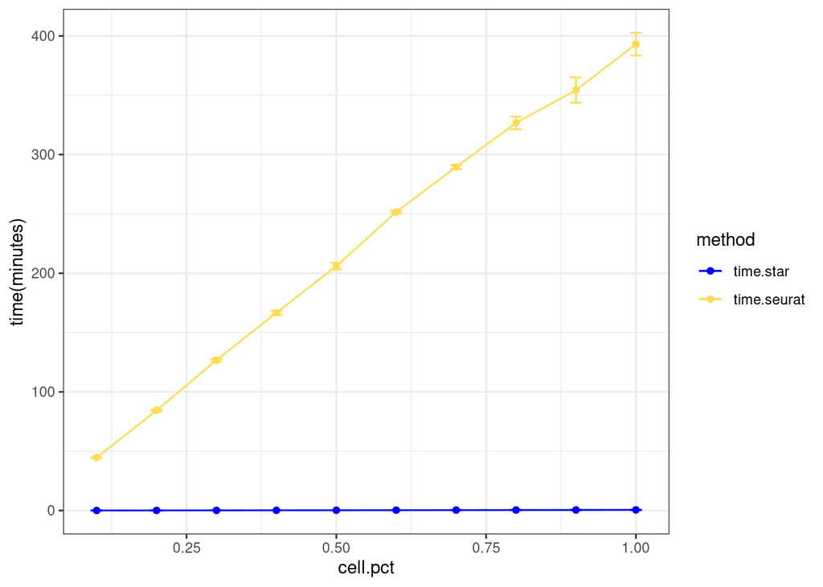

```r
mat <- time.seurat.star.size
mat <- mat[,c(2,3,4,5)] %>% reshape2::melt(id.var = c("cell.pct","variable"))
mat$value <- mat$value/60
colnames(mat)[2:3] <- c("time","method")

mat.use <- Rmisc::summarySE(mat, measurevar = "value", groupvar = c("cell.pct","method"))

(p <- ggplot(data = mat.use,aes(x = cell.pct, y = value, color = method, group = method)) +
  #facet_grid(method~.) +
  geom_errorbar(aes(ymin = value - se, ymax = value + se), width = 0.02) +
  geom_line() + geom_point() +
  scale_color_manual(values = c("blue","#fcdc57")) + theme_bw() + ylab("time(minutes)"))
```

# 4 Calulate the Specificity of Marker Genes

Same as in `brain.Rmd`, we will run the `seachMarker` function again. This time we choose to get 5 marker genes in each group. This result will be used to calculate Ti in each cluster.

Ti is defined as

$$T_i=\frac{\mathrm{card}\ \left(\mathrm{G}_\mathrm{i}\mathrm{\cap}\
\mathrm{G}_{\mathrm{clust}}\right)}{\mathrm{card}\left(\mathrm{G}_\mathrm{i}\right)}$$

Where:

Gi represents the set of the cells expressing gene i *in-silico*.

Gclust represents the set of cells where gene i serves as the *in-silico* marker gene.

## 4.1 Specificity of the Marker Genes Found by starTracer

```r
frame.star <- starTracer::searchMarker(heart_big,thresh.1 = 0.5,thresh.2 = 0.3,num = 5,gene.use = "HVG")
frame.star <- subset(frame.star$para_frame,frame.star$para_frame$gene %in% frame.star$genes.markers)[,c("max.X","gene")]
colnames(frame.star)[1] <- "cluster"
frame.star <- cal_spe(heart_big,ident.use = "cell_type__ontology_label",frame.star)
```

Let’s see `frame.star` . A new column named `pct.pos` is added into the `data.frame`

```r
frame.star %>% head()
```

```
##                        cluster       gene   pct.pos
## LINC01954  cardiac muscle cell  LINC01954 0.9983669
## AC018464.1 cardiac muscle cell AC018464.1 0.9976938
## AC021134.1 cardiac muscle cell AC021134.1 0.9979532
## POPDC2     cardiac muscle cell     POPDC2 0.9973631
## MYL3       cardiac muscle cell       MYL3 0.9969686
## ADIPOQ-AS1            fat cell ADIPOQ-AS1 0.9326861
```

## 4.2 Specificity of the Marker Genes Found by Seurat

We run `heart_bigdata_findAllMArkers` in the command line and load the results into R.

```r
load("./out/f2_bigdata/heart_big.Seurat.Rdata")
```

Generating the frame of Seurat:

1. Find marker genes using FindAllMarkers function.
2. Subset the matrix by setting p-value < 0.05
3. re-arrange the data.frame by cluster and descending average log2(Fold-Change)
4. Keep the top 10 marker gene in each cluster

```r
gene.seurat <- subset(heart_big.Seurat,heart_big.Seurat$p_val_adj < 0.05)
gene.seurat <- arrange(gene.seurat,cluster,desc(avg_log2FC))
gene.seurat <- with(gene.seurat,by(gene.seurat[,"gene"],INDICES = cluster,FUN = function(x)head(x,10))) %>% unlist() %>% as.vector() %>% rev()
```

```r
frame.seurat <- heart_big.Seurat[,c("cluster","gene","avg_log2FC")] %>% subset(heart_big.Seurat$gene %in% gene.seurat)
frame.seurat <- arrange(frame.seurat,gene,desc(avg_log2FC))
frame.seurat <- frame.seurat[!duplicated(frame.seurat$gene),] %>% arrange(cluster,desc(avg_log2FC))

frame.seurat <- frame.seurat %>%
  group_by(cluster) %>% #按照cluster列进行分组
  top_n(5, wt = avg_log2FC) %>% #按照FC列从大到小排序，选择每组前2行
  ungroup()
frame.seurat$cluster %>% table()

#this is used to draw graphs
frame.seurat.p <- frame.seurat %>%
  group_by(cluster) %>%
  top_n(3, wt = avg_log2FC) %>%
  ungroup()
frame.seurat.p$cluster %>% table() %>% head()
```

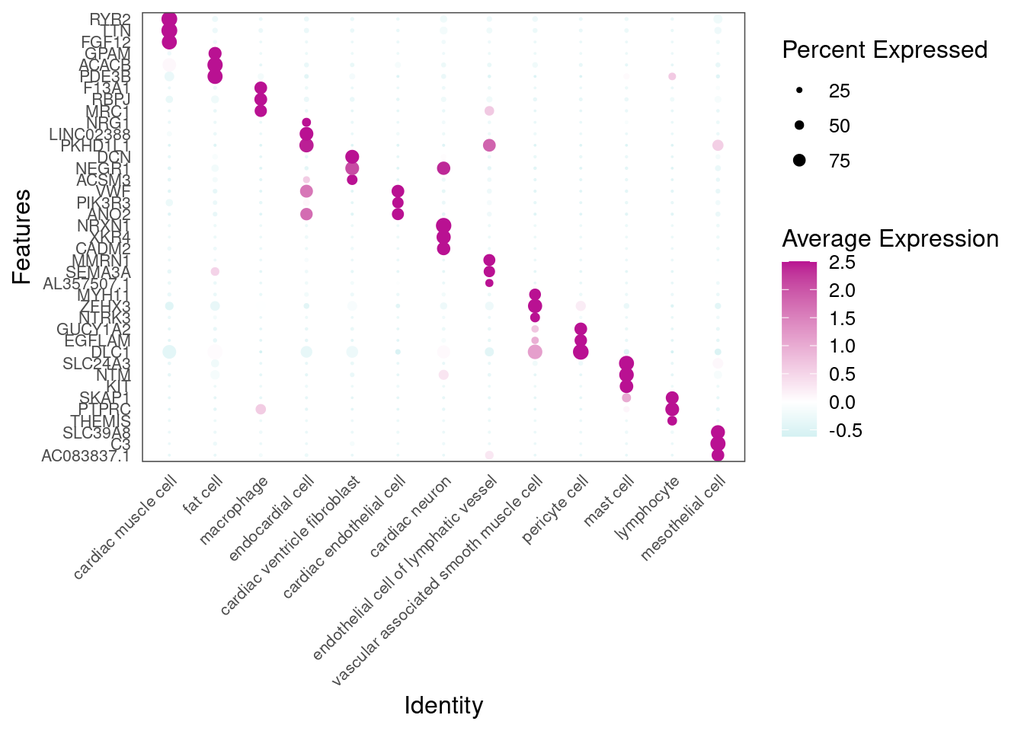

```r
(p <- use_dotplot(heart_big,features = rev(frame.seurat.p$gene), colors.gradient = c("#13c4cd","#ffffff","#b91192"),dot.scale = 3))
```

Every cluster has 5 marker genes. Calculating the Ti will cost a lot of time, especially for samples with large number of cells.

```r
frame.seurat <- frame.seurat[,c("cluster","gene")]
frame.seurat <- cal_spe(heart_big,ident.use = "cell_type__ontology_label",as.data.frame(frame.seurat))
```

Show the result of `frame.seurat` . A new column `pct.pos` is added

```r
frame.seurat %>% head()
```

```
##               cluster    gene   pct.pos
## 1 cardiac muscle cell    RYR2 0.8113210
## 2 cardiac muscle cell     TTN 0.7855700
## 3 cardiac muscle cell   FGF12 0.9745717
## 4 cardiac muscle cell  SORBS2 0.9106256
## 5 cardiac muscle cell TTN-AS1 0.8743483
## 6            fat cell    GPAM 0.1781039
```

## 4.3 Find the Difference of the Specificity of Marker genes found by Seurat and starTracer

Same as described previously, we will not include the t.test results in the final results.

```r
frame.pct.pos <- data.frame(cluster = frame.star$cluster,pct.star = frame.star$pct.pos,pct.seurat = frame.seurat$pct.pos)

#cal seurat.mean
frame.pct.pos$pct.seurat.mean <- rep(aggregate(pct.seurat ~ cluster, data = frame.pct.pos, FUN = mean)$pct.seurat,each = 5)

#divide seurat.mean to get star.adk and seurat.adj
frame.pct.pos$pct.seurat.adj <- frame.pct.pos$pct.seurat/frame.pct.pos$pct.seurat.mean
frame.pct.pos$pct.star.adj <- frame.pct.pos$pct.star/frame.pct.pos$pct.seurat.mean

#cal star.adj.mean to arrange the plot
frame.pct.pos$pct.star.adj.mean <- rep(aggregate(pct.star.adj ~ cluster, data = frame.pct.pos, FUN = mean)$pct.star.adj,each = 5)

#arrange
frame.pct.pos <- arrange(frame.pct.pos,desc(pct.star.adj.mean))
frame.pct.pos$cluster <- factor(frame.pct.pos$cluster,levels = unique(frame.pct.pos$cluster))

p <- c()
foldchange <- c()
for (i in unique(frame.pct.pos$cluster)){
  mat <- subset(frame.pct.pos,cluster == i)
  t1 <- mat$pct.star
  t2 <- mat$pct.seurat
  p.i <- t.test(t1,t2)$p.value
  foldchange.i <- mean(mat$pct.star)/mean(mat$pct.seurat)

  foldchange <- append(foldchange,foldchange.i)
  p <- append(p,p.i)
}
frame.pct.pos.stat <- data.frame(cluster = unique(frame.pct.pos$cluster),p = p, foldchange = foldchange)
```

Visualize

```r
mat.use <- reshape2::melt(frame.pct.pos[,c(1,5,6)])
```

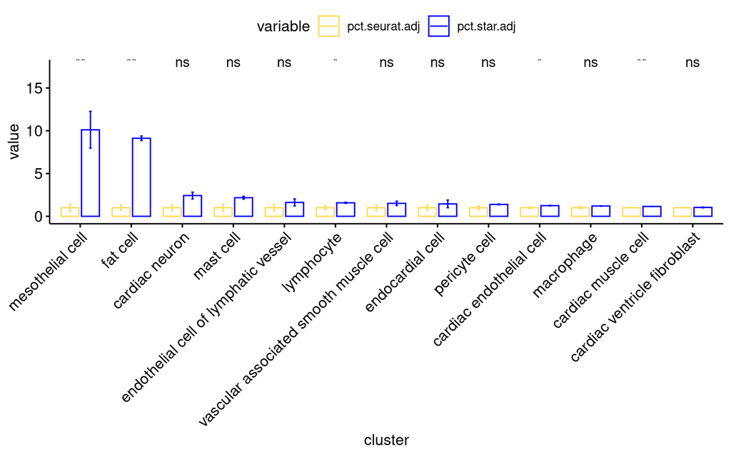

```r
(p <- ggbarplot(mat.use, x = "cluster", y = "value", add = c("mean_se"),color = "variable",fill = "white",palette = c("#fcdc57","blue"),
          position = position_dodge(0.8)) + stat_compare_means(aes(group = variable), label = "p.signif",method = "wilcox") + theme(axis.text.x = element_text(angle = 45,hjust = 1)))
```